# MILESTONE EXAM 1

Shirisha Biyyala

Due: October 2, 2024

## Academic Honesty Statement

I, Shirisha Biyyala, hereby state that I have not communicated with or gained information in any way from my classmates or anyone other than the Professor or TA during this exam, and that all work is my own.

## Questions

#### Understand the dataset

This section allows us to view the entire `flights` dataset from the `nycflights13` package. It also provides access to documentation for understanding the datasets’ variables and attributes.

```
## starting httpd help server ... done
```

In this section, we extract the first few rows of the `flights` dataset to get a **glimpse of the data**.

| year | month | day | dep_time | sched_dep_time | dep_delay | arr_time | sched_arr_time | arr_delay | carrier | flight | tailnum | origin | dest | air_time | distance | hour | minute | time_hour |
| --- | --- | --- | --- | --- | --- | --- | --- | --- | --- | --- | --- | --- | --- | --- | --- | --- | --- | --- |
| 2013 | 1 | 1 | 517 | 515 | 2 | 830 | 819 | 11 | UA | 1545 | N14228 | EWR | IAH | 227 | 1400 | 5 | 15 | 2013-01-01 05:00:00 |
| 2013 | 1 | 1 | 533 | 529 | 4 | 850 | 830 | 20 | UA | 1714 | N24211 | LGA | IAH | 227 | 1416 | 5 | 29 | 2013-01-01 05:00:00 |
| 2013 | 1 | 1 | 542 | 540 | 2 | 923 | 850 | 33 | AA | 1141 | N619AA | JFK | MIA | 160 | 1089 | 5 | 40 | 2013-01-01 05:00:00 |
| 2013 | 1 | 1 | 544 | 545 | -1 | 1004 | 1022 | -18 | B6 | 725 | N804JB | JFK | BQN | 183 | 1576 | 5 | 45 | 2013-01-01 05:00:00 |
| 2013 | 1 | 1 | 554 | 600 | -6 | 812 | 837 | -25 | DL | 461 | N668DN | LGA | ATL | 116 | 762 | 6 | 0 | 2013-01-01 06:00:00 |
| 2013 | 1 | 1 | 554 | 558 | -4 | 740 | 728 | 12 | UA | 1696 | N39463 | EWR | ORD | 150 | 719 | 5 | 58 | 2013-01-01 05:00:00 |

#### Exploratory Data Analysis

This section conducts an initial **exploratory analysis** by checking the structure of the `flights` dataset using glimpse, which provides a compact view of the data types and sample values. It counts the number of missing values in each column to identify potential issues with data completeness. Finally, **summary statistics** are generated for key features like departure delay, arrival delay, distance, and airtime, allowing for a better understanding of flight performance and trends.

```
## Rows: 336,776
## Columns: 19
## $ year           <int> 2013, 2013, 2013, 2013, 2013, 2013, 2013, 2013, 2013, 2…
## $ month          <int> 1, 1, 1, 1, 1, 1, 1, 1, 1, 1, 1, 1, 1, 1, 1, 1, 1, 1, 1…
## $ day            <int> 1, 1, 1, 1, 1, 1, 1, 1, 1, 1, 1, 1, 1, 1, 1, 1, 1, 1, 1…
## $ dep_time       <int> 517, 533, 542, 544, 554, 554, 555, 557, 557, 558, 558, …
## $ sched_dep_time <int> 515, 529, 540, 545, 600, 558, 600, 600, 600, 600, 600, …
## $ dep_delay      <dbl> 2, 4, 2, -1, -6, -4, -5, -3, -3, -2, -2, -2, -2, -2, -1…
## $ arr_time       <int> 830, 850, 923, 1004, 812, 740, 913, 709, 838, 753, 849,…
## $ sched_arr_time <int> 819, 830, 850, 1022, 837, 728, 854, 723, 846, 745, 851,…
## $ arr_delay      <dbl> 11, 20, 33, -18, -25, 12, 19, -14, -8, 8, -2, -3, 7, -1…
## $ carrier        <chr> "UA", "UA", "AA", "B6", "DL", "UA", "B6", "EV", "B6", "…
## $ flight         <int> 1545, 1714, 1141, 725, 461, 1696, 507, 5708, 79, 301, 4…
## $ tailnum        <chr> "N14228", "N24211", "N619AA", "N804JB", "N668DN", "N394…
## $ origin         <chr> "EWR", "LGA", "JFK", "JFK", "LGA", "EWR", "EWR", "LGA",…
## $ dest           <chr> "IAH", "IAH", "MIA", "BQN", "ATL", "ORD", "FLL", "IAD",…
## $ air_time       <dbl> 227, 227, 160, 183, 116, 150, 158, 53, 140, 138, 149, 1…
## $ distance       <dbl> 1400, 1416, 1089, 1576, 762, 719, 1065, 229, 944, 733, …
## $ hour           <dbl> 5, 5, 5, 5, 6, 5, 6, 6, 6, 6, 6, 6, 6, 6, 6, 5, 6, 6, 6…
## $ minute         <dbl> 15, 29, 40, 45, 0, 58, 0, 0, 0, 0, 0, 0, 0, 0, 0, 59, 0…
## $ time_hour      <dttm> 2013-01-01 05:00:00, 2013-01-01 05:00:00, 2013-01-01 0…
```

```
##           year          month            day       dep_time sched_dep_time
##              0              0              0           8255              0
##      dep_delay       arr_time sched_arr_time      arr_delay        carrier
##           8255           8713              0           9430              0
##         flight        tailnum         origin           dest       air_time
##              0           2512              0              0           9430
##       distance           hour         minute      time_hour
##              0              0              0              0
```

```
##    dep_delay         arr_delay           distance       air_time
##  Min.   : -43.00   Min.   : -86.000   Min.   :  17   Min.   : 20.0
##  1st Qu.:  -5.00   1st Qu.: -17.000   1st Qu.: 502   1st Qu.: 82.0
##  Median :  -2.00   Median :  -5.000   Median : 872   Median :129.0
##  Mean   :  12.64   Mean   :   6.895   Mean   :1040   Mean   :150.7
##  3rd Qu.:  11.00   3rd Qu.:  14.000   3rd Qu.:1389   3rd Qu.:192.0
##  Max.   :1301.00   Max.   :1272.000   Max.   :4983   Max.   :695.0
##  NA's   :8255      NA's   :9430                      NA's   :9430
```

#### References

1. https://sebastiansauer.github.io/sum-isna/

### Question 1

To identify the **ten most common flight destinations** from NYC airports in 2013, I grouped the flights dataset by the `dest` column and counted the number of flights to each destination. After *sorting* the results in descending order, I selected the top ten destinations.

```
## # A tibble: 10 × 2
##    dest  flight_count
##    <chr>        <int>
##  1 ORD          17283
##  2 ATL          17215
##  3 LAX          16174
##  4 BOS          15508
##  5 MCO          14082
##  6 CLT          14064
##  7 SFO          13331
##  8 FLL          12055
##  9 MIA          11728
## 10 DCA           9705
```

From the table, we can see that **ORD** had the highest number of flights from NYC, followed closely by **ATL** and **LAX**. This indicates that these cities were the most popular destinations for travelers flying out of New York City in 2013.

### Question 2

To determine which airlines had the **most flights departing** from NYC airports in 2013, I grouped the `flights` dataset by the `carrier` column and calculated the total number of flights for each airline. I then joined this data with the airlines dataset to retrieve the airline names, sorted the results in descending order, and presented the flight counts alongside their respective airline names.

```
## # A tibble: 16 × 3
##    carrier flight_count airline_name
##    <chr>          <int> <chr>
##  1 UA             58665 United Air Lines Inc.
##  2 B6             54635 JetBlue Airways
##  3 EV             54173 ExpressJet Airlines Inc.
##  4 DL             48110 Delta Air Lines Inc.
##  5 AA             32729 American Airlines Inc.
##  6 MQ             26397 Envoy Air
##  7 US             20536 US Airways Inc.
##  8 9E             18460 Endeavor Air Inc.
##  9 WN             12275 Southwest Airlines Co.
## 10 VX              5162 Virgin America
## 11 FL              3260 AirTran Airways Corporation
## 12 AS               714 Alaska Airlines Inc.
## 13 F9               685 Frontier Airlines Inc.
## 14 YV               601 Mesa Airlines Inc.
## 15 HA               342 Hawaiian Airlines Inc.
## 16 OO                32 SkyWest Airlines Inc.
```

From the table, we can see that **United Air Lines Inc.** (58665) had the highest number of flights from NYC, followed by **JetBlue Airways**(54635) and **ExpressJet Airlines Inc.**(54173) This highlights the dominance of these airlines in the NYC air travel market during 2013.

### Question 3

To analyze the **arrival delays of flights** with non-missing delay information, I filtered the `flights` dataset to exclude any rows where the `arr_delay` value is missing. I then grouped the data by the `carrier` column, calculating the *mean arrival delay for each airline*. After sorting the results, I identified the carrier with the **highest and lowest mean arrival delays**, along with their corresponding carrier codes.

```
## # A tibble: 16 × 3
##    carrier mean_arr_delay name
##    <chr>            <dbl> <chr>
##  1 F9              21.9   Frontier Airlines Inc.
##  2 FL              20.1   AirTran Airways Corporation
##  3 EV              15.8   ExpressJet Airlines Inc.
##  4 YV              15.6   Mesa Airlines Inc.
##  5 OO              11.9   SkyWest Airlines Inc.
##  6 MQ              10.8   Envoy Air
##  7 WN               9.65  Southwest Airlines Co.
##  8 B6               9.46  JetBlue Airways
##  9 9E               7.38  Endeavor Air Inc.
## 10 UA               3.56  United Air Lines Inc.
## 11 US               2.13  US Airways Inc.
## 12 VX               1.76  Virgin America
## 13 DL               1.64  Delta Air Lines Inc.
## 14 AA               0.364 American Airlines Inc.
## 15 HA              -6.92  Hawaiian Airlines Inc.
## 16 AS              -9.93  Alaska Airlines Inc.
```

#### Highest mean arrival delay

The carrier with the highest mean arrival delay is **Frontier Airlines Inc. (F9)**, with an average delay of **21.92 minutes**. This indicates that, on average, flights operated by Frontier Airlines arrived nearly **22 minutes later** than their scheduled time, suggesting potential operational challenges affecting punctuality.

#### Lowest mean arrival delay

Conversely, **Alaska Airlines Inc. (AS)** had the lowest mean arrival delay, averaging **-9.93 minutes**. This negative value indicates that, on average, Alaska Airlines flights arrived about **10 minutes earlier** than scheduled. This suggests that Alaska Airlines was the most punctual among the carriers analyzed, performing well in terms of timely arrivals.

#### References

1. https://stackoverflow.com/questions/66422564/round-numbers-in-r-correctly

### Question 4

In this code, we’re working on **identifying the mean temperature at the origin airport** on the day with the highest total departure delay in 2013.

#### Step 4.1: Find the Day with the Highest Departure Delay

```
## # A tibble: 1 × 4
##    year month   day total_dep_delay
##   <int> <int> <int>           <dbl>
## 1  2013     3     8           66746
```

The goal here is to group `flights` by date (`year`, `month`, `day`) and calculate the total departure delay for each day. By using `arrange(desc(total_dep_delay))`, the days are sorted in descending order of total delay, and `slice(1)` selects the day with the maximum total delay. This gives us the specific date to focus on.

From this table, we identified that **March 8, 2013**, had the highest total departure delay, amounting to **66,746 minutes**. This indicates that on this particular day, there was a significant disruption at NYC airports, causing extensive delays across multiple flights.

#### Step 4.2: Join Flights with Weather Data

Initially, a warning was triggered due to multiple rows from both datasets matching each other on the same day and airport, creating a many-to-many relationship. To handle this, we first combined the weather data by grouping it by year, month, day, and origin. This ensures that for each origin airport on each day, we have a single temperature value.

We calculate the daily mean temperature using the `mean(temp, na.rm = TRUE)` function. By grouping and summarizing, we ensure that when joining the flight data with the weather data, the join operation provides a unique temperature value for each origin on each specific day.

```
## # A tibble: 3 × 3
##   origin date       mean_temperature
##   <chr>  <date>                <dbl>
## 1 EWR    2013-03-08             35.3
## 2 JFK    2013-03-08             35.0
## 3 LGA    2013-03-08             36.3
```

This table provides the mean temperature at each of the three NYC airports (JFK, EWR, and LGA) on March 8, 2013:

- **JFK**: The mean temperature was **34.97°F**.
- **EWR**: The mean temperature was **35.31°F**.
- **LGA**: The mean temperature was **36.34°F**.

This gives us insight into the weather conditions on the day with the most significant departure delays. Although the temperatures were close to each other across the three airports, all hovered around the mid-30s Fahrenheit, which is relatively cool and might have contributed to flight delays, especially if there were additional weather factors like wind or precipitation.

#### Conclusion:

The day with the highest total departure delay was **March 8, 2013**, with a total delay of **66,746 minutes**. The mean temperatures at the NYC airports on that day were around **35°F**, but further investigation into specific weather events (e.g., storms) may explain why such extensive delays occurred.

#### References

1. https://stackoverflow.com/questions/39420136/combine-separate-year-and-month-columns-into-single-date-column
2. https://dplyr.tidyverse.org/reference/mutate-joins.html

### Question 5

The code filters flights to exclude those with missing departure delays, then categorizes the remaining flights into *four time intervals* based on their departure times using the `case_when()` function. It groups the data by these intervals, calculating the total number of flights and the count of delayed flights for each interval. The proportion of delayed flights is calculated using the formula:

$$\text{Proportion of Delayed Flights} = \frac{\text{Delayed
Flights}}{\text{Total Flights}}$$

Finally, it sorts the intervals in chronological order to provide a clear view of how delays fluctuate throughout the day.

```
## # A tibble: 4 × 4
##   time_interval total_flights delayed_flights prop_delayed
##   <chr>                 <int>           <int>        <dbl>
## 1 12:01am-6am            9344            1553        0.166
## 2 12:01pm-6pm          120738           53151        0.440
## 3 6:01am-12pm          122082           30178        0.247
## 4 6:01pm-12am           76357           43550        0.570
```

#### Key Findings:

**Early Morning (12:01am-6am):**  
This period shows the lowest proportion of delayed flights at 16.6%. Fewer flights and reduced airport congestion during the early hours may contribute to this.

**Morning (6:01am-12pm):**  
The proportion of delayed flights rises to 24.7%. This could be due to increased air traffic as more flights depart during the morning, leading to slight operational delays.

**Afternoon (12:01pm-6pm):**  
During this period, delays become more frequent, with 44% of flights delayed. The afternoon tends to have heavy air traffic, and delays from earlier in the day can accumulate.

**Evening (6:01pm-12am):**  
The likelihood of delay is highest in the evening, with 57% of flights experiencing delays. This suggests that delays compound as the day progresses, resulting in more late departures by evening.

#### Conclusion:

The analysis shows that the chances of a flight being delayed at departure steadily increase throughout the day. Early morning flights are the least likely to be delayed, while flights departing in the evening face a much higher probability of delay. This pattern is likely due to the buildup of delays from earlier flights, increasing congestion, and operational challenges during peak travel times.

#### References

1. https://stackoverflow.com/a/64980831

### Question 6

The code identifies the flight with the longest air time from the `flights` dataset while also retrieving relevant details about the aircraft from the `planes` dataset, including its seating capacity.

First, the code extracts essential information regarding the longest flight, such as the flight number, destination, air time, year, month, and day of departure. Next, it filters the `planes` dataset to find the corresponding aircraft by matching the tail number of the longest flight (`longest_flight$tailnum`), ensuring that the correct plane is referenced. Finally, the code utilizes the `mutate` function to combine the information about the longest flight with the number of seats, adding a new column called `seats` to the `longest_flight_info` data frame.

```
## # A tibble: 1 × 7
##   flight destination air_time  year month   day seats
##    <int> <chr>          <dbl> <int> <int> <int> <int>
## 1     15 HNL              695  2013     3    17   292
```

#### Interpretation

**How long is this flight?**

The flight has an air time of **695 minutes**, which translates to approximately **11 hours and 35 minutes**. This significant duration indicates it is a long-haul flight, reflecting the distance between NYC and HNL.

**What city did it fly to?**

The destination of this flight is **HNL**, located in Hawaii.

**How many seats does the plane that flew this flight have?**

The aircraft that operated this flight has a seating capacity of **292 seats**. This large capacity suggests that the airline is equipped to handle a significant number of passengers.

#### References

1. https://nycflights13.tidyverse.org/reference/planes.html

### Question 7

To analyze the geographical distribution of airports in the *Contiguous United States*, we will visualize the longitudes of the airports. First, we need to filter based on the **latitude and longitude coordinates** that correspond to the contiguous United States.

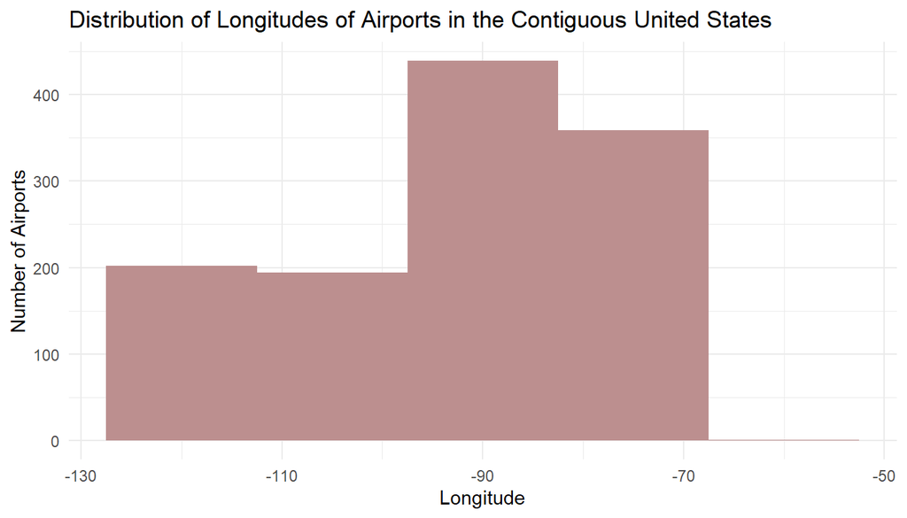

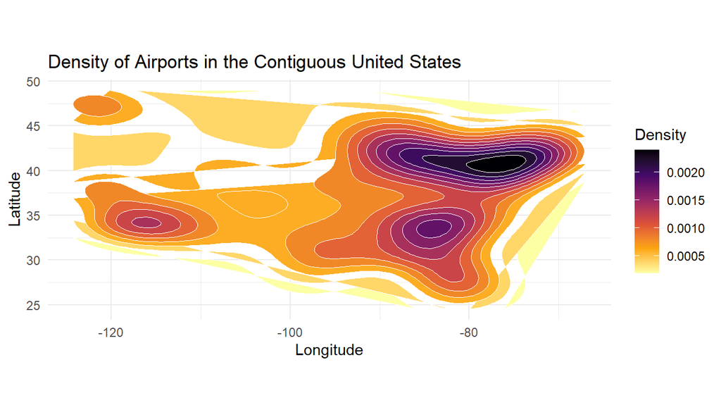

[interactive chart not shown]

#### Interpretation of the Visualizations

The histogram displays the distribution of longitudes for airports located in the Contiguous United States.

#### References

1. https://qr.ae/p25ElE
2. https://qr.ae/p25E6R
3. https://r-charts.com/spatial/interactive-maps-leaflet/

### Question 8

This visualization displays the relationship between flight arrival status (“ontime” or “delayed”) and departure delays across three major New York City airports (EWR, JFK, LGA) and two destinations (PHL and RDU) for flights in December 2013. Each boxplot shows the distribution of departure delays for flights that either arrived on time or were delayed. The use of faceting allows us to compare the performance of different airport pairs.

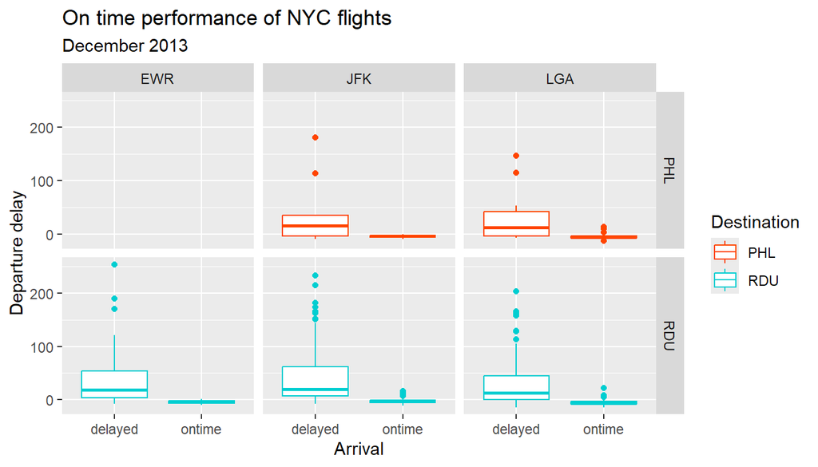

#### Interpretation

The point of this visualization might be to illustrate how departure delays relate to arrival delays and whether certain airports or destinations exhibit more delay patterns. For example, it can help identify if flights departing from specific airports, like EWR or JFK, are more prone to departure delays that lead to late arrivals at PHL or RDU.

### Extra Credit

The scatter plot provides a visual representation of the relationship between the average daily departure delay and the average daily temperature for flights departing from the three New York City airports: EWR, JFK, and LGA.

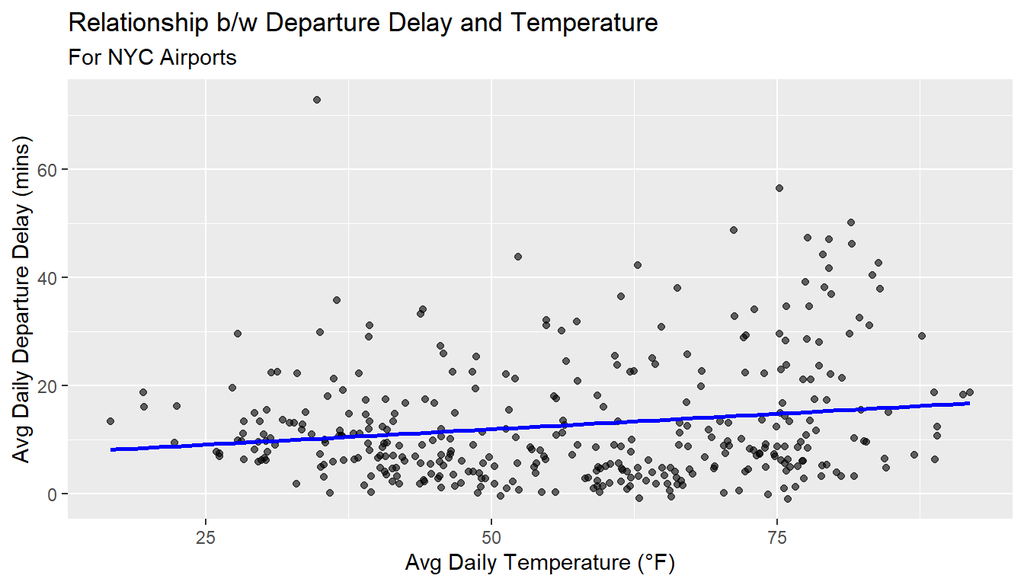

From the graph, we can see a **slight upward trend**, showing that as the average daily temperature goes up, the average departure delay tends to increase as well. This implies that warmer temperatures might be linked to longer flight delays. The blue regression line reinforces this trend, illustrating a **positive slope**. However, the points are spread out around the regression line, suggesting that, although there is a general relationship, other factors likely play a role in influencing the departure delays.

#### References

1. https://www.rpubs.com/Katharhy/853651
2. https://clauswilke.com/dataviz/visualizing-associations.html